# Covid-19 Data - Analyze / Visualize / Model

Kothandaraman Sikamani

12/02/2022

# Covid 19 Global/US data analyzing and modeling

# Purpose

In this document, I will be explaining/focusing on Analytics, Visualization, and Model building using Covid-19 Data Dataset from John Hopkins University. At a high level, I will be addressing the following topics.

1. **Covid Cases from Global/US.**
   - Summarizing global covid-19 cases
   - Summarizing global covid-19 deaths
   - Summarizing US covid-19 cases
   - Summarizing US covid-19 deaths
2. **Tidying and Transforming Data**
   - Summarizing US covid-19 cases
   - Summarizing US covid-19 deaths
3. **Visualization and Analysis for Covid-19 cases from Global/US.**
   - Visualization of state wise cases/deaths using plots.
   - Analyzing state wise data
   - Analyzing state wise maximum cases and deaths
4. **Model.**
   - Data preparation for Model
   - LM model building
   - Summarizing and analyzing model.
   - Understanding model predictions and plot the model prediction visually.
5. **Bias.**
   - Describe if any bias situations that can help improve model performance.

## Data Source

I am using the data source from John Hopkins github for US/Global cases/deaths as csv format https://github.com/CSSEGISandData/COVID-19/tree/master/csse_covid_19_data/csse_covid_19_time_series/

# From file URL’s

```r
url_in <- "https://raw.githubusercontent.com/CSSEGISandData/COVID-19/master/csse_covid_19_data/csse_covid_19_time_series/"

file_names <- c("time_series_covid19_confirmed_global.csv",
                "time_series_covid19_deaths_global.csv",
                "time_series_covid19_confirmed_US.csv",
                "time_series_covid19_deaths_US.csv"
                )

urls <- str_c(url_in, file_names)

#urls
```

## Import the global data

I will read the .csv file using read.csv()

```r
# Reading global cases and deaths raw csv data

global_cases <- read.csv(urls[1])
global_deaths <- read.csv(urls[2])

#global_cases.
#head(global_cases, 5)
#global_deaths
#head(global_deaths, 5)
```

# 1. Covid Cases from Global/US Raw data

```r
# Sumamry global covid-19 cases
#summary(global_cases)

# Sumamry global covid-19 deaths
#summary(global_deaths)

#data.table(global_cases)
#data.table(global_deaths)

global_cases <- global_cases %>%
  pivot_longer(cols = -c('Province.State',
                         'Country.Region', Lat, Long),
               names_to = "date",
               values_to = "cases") %>%
  select(-c(Lat, Long))

global_deaths <- global_deaths %>%
  pivot_longer(cols = -c('Province.State',
                         'Country.Region', Lat, Long),
               names_to = "date",
               values_to = "deaths") %>%
  select(-c(Lat, Long))

# Sumamry global covid-19 cases
summary(global_cases)
```

```
##  Province.State     Country.Region         date               cases
##  Length:212346      Length:212346      Length:212346      Min.   :       0
##  Class :character   Class :character   Class :character   1st Qu.:     201
##  Mode  :character   Mode  :character   Mode  :character   Median :    4359
##                                                           Mean   :  422912
##                                                           3rd Qu.:   87213
##                                                           Max.   :77707349
```

```r
# Sumamry global covid-19 deaths
summary(global_deaths)
```

```
##  Province.State     Country.Region         date               deaths
##  Length:212346      Length:212346      Length:212346      Min.   :     0
##  Class :character   Class :character   Class :character   1st Qu.:     2
##  Mode  :character   Mode  :character   Mode  :character   Median :    62
##                                                           Mean   :  8864
##                                                           3rd Qu.:  1478
##                                                           Max.   :919255
```

```r
#data.table(global_cases)
#data.table(global_deaths)

#data.table(global_cases)
#data.table(global_deaths)



# 1.1 Data Cleanup



#global_cases <- global_cases[1:100, ]
#global_deaths <- global_deaths[1:100, ]

# Cleanup Data - Date column
global_cases$date <- gsub("\\.", "-", global_cases$date)
global_cases$date <- gsub("\\X", "", global_cases$date)
global_deaths$date <- gsub("\\.", "-", global_deaths$date)
global_deaths$date <- gsub("\\X", "", global_deaths$date)

global_cases <- global_cases %>%
   mutate(date = mdy(date))
global_deaths <- global_deaths %>%
   mutate(date = mdy(date))

# Join global cases with deaths
global <- global_cases %>%
   full_join(global_deaths)
# Column rename
global <- global %>%
   rename(Country_Region = `Country.Region`,
           Province_State = `Province.State`)
```

# 2. Tidying and Transforming Data:

```r
## Import the US data
# I will read the .csv file using read.csv()


us_cases <- read.csv(urls[3])
us_deaths <- read.csv(urls[4])

#us_cases
#us_deaths
#summary(us_cases)
#summary(us_deaths)
#data.table(us_cases)
#data.table(us_deaths)

# Data Cleaup
 us_cases <- us_cases %>%
   pivot_longer(cols = -c('Province_State',
                          'Country_Region', UID, iso2, iso3, code3, FIPS,
                          Combined_Key, Admin2, Lat, Long_),
                names_to = "date",
                values_to = "cases") %>%
   select(-c(UID, iso2, iso3, code3, FIPS, Lat, Long_))

 us_deaths <- us_deaths %>%
   pivot_longer(cols = -c('Province_State',
                          'Country_Region', UID, iso2, iso3, code3, FIPS,
                          Combined_Key, Population, Admin2, Lat, Long_),
                names_to = "date",
                values_to = "deaths") %>%
   select(-c(UID, iso2, iso3, code3, FIPS, Lat, Long_))

us_cases$date <- gsub("\\.", "-", us_cases$date)
us_cases$date <- gsub("\\X", "", us_cases$date)
us_deaths$date <- gsub("\\.", "-", us_deaths$date)
us_deaths$date <- gsub("\\X", "", us_deaths$date)

us_cases <- us_cases %>%
   mutate(date = mdy(date))
us_deaths <- us_deaths %>%
   mutate(date = mdy(date))

us_cases
```

```
## # A tibble: 2,516,526 × 6
##    Admin2  Province_State Country_Region Combined_Key         date       cases
##    <chr>   <chr>          <chr>          <chr>                <date>     <int>
##  1 Autauga Alabama        US             Autauga, Alabama, US 2020-01-22     0
##  2 Autauga Alabama        US             Autauga, Alabama, US 2020-01-23     0
##  3 Autauga Alabama        US             Autauga, Alabama, US 2020-01-24     0
##  4 Autauga Alabama        US             Autauga, Alabama, US 2020-01-25     0
##  5 Autauga Alabama        US             Autauga, Alabama, US 2020-01-26     0
##  6 Autauga Alabama        US             Autauga, Alabama, US 2020-01-27     0
##  7 Autauga Alabama        US             Autauga, Alabama, US 2020-01-28     0
##  8 Autauga Alabama        US             Autauga, Alabama, US 2020-01-29     0
##  9 Autauga Alabama        US             Autauga, Alabama, US 2020-01-30     0
## 10 Autauga Alabama        US             Autauga, Alabama, US 2020-01-31     0
## # … with 2,516,516 more rows
```

```r
us_deaths
```

```
## # A tibble: 2,516,526 × 7
##    Admin2  Province_State Country_Region Combined_Key      Population date
##    <chr>   <chr>          <chr>          <chr>                  <int> <date>
##  1 Autauga Alabama        US             Autauga, Alabama…      55869 2020-01-22
##  2 Autauga Alabama        US             Autauga, Alabama…      55869 2020-01-23
##  3 Autauga Alabama        US             Autauga, Alabama…      55869 2020-01-24
##  4 Autauga Alabama        US             Autauga, Alabama…      55869 2020-01-25
##  5 Autauga Alabama        US             Autauga, Alabama…      55869 2020-01-26
##  6 Autauga Alabama        US             Autauga, Alabama…      55869 2020-01-27
##  7 Autauga Alabama        US             Autauga, Alabama…      55869 2020-01-28
##  8 Autauga Alabama        US             Autauga, Alabama…      55869 2020-01-29
##  9 Autauga Alabama        US             Autauga, Alabama…      55869 2020-01-30
## 10 Autauga Alabama        US             Autauga, Alabama…      55869 2020-01-31
## # … with 2,516,516 more rows, and 1 more variable: deaths <int>
```

```r
# Summarizing US cases:
summary(us_cases)
```

```
##     Admin2          Province_State     Country_Region     Combined_Key
##  Length:2516526     Length:2516526     Length:2516526     Length:2516526
##  Class :character   Class :character   Class :character   Class :character
##  Mode  :character   Mode  :character   Mode  :character   Mode  :character
##
##
##
##       date                cases
##  Min.   :2020-01-22   Min.   :      0
##  1st Qu.:2020-07-28   1st Qu.:     76
##  Median :2021-02-01   Median :   1017
##  Mean   :2021-02-01   Mean   :   7133
##  3rd Qu.:2021-08-08   3rd Qu.:   4016
##  Max.   :2022-02-12   Max.   :2757058
```

```r
# Summarizing US Deaths:
summary(us_deaths)
```

```
##     Admin2          Province_State     Country_Region     Combined_Key
##  Length:2516526     Length:2516526     Length:2516526     Length:2516526
##  Class :character   Class :character   Class :character   Class :character
##  Mode  :character   Mode  :character   Mode  :character   Mode  :character
##
##
##
##    Population            date                deaths
##  Min.   :       0   Min.   :2020-01-22   Min.   :    0.0
##  1st Qu.:    9917   1st Qu.:2020-07-28   1st Qu.:    1.0
##  Median :   24892   Median :2021-02-01   Median :   18.0
##  Mean   :   99604   Mean   :2021-02-01   Mean   :  122.7
##  3rd Qu.:   64979   3rd Qu.:2021-08-08   3rd Qu.:   72.0
##  Max.   :10039107   Max.   :2022-02-12   Max.   :29846.0
```

```r
# data.table(us_cases)
# data.table(us_deaths)

# Join us_cases data with us_deaths dataset

US <- us_cases %>%
   full_join(us_deaths)
```

[output not shown]

```r
# Create Combined_Key column in global dataframe using Province_State, Country_Region)
# Column rename
global <- global %>%
   unite("Combined_Key",
           c(Province_State, Country_Region),
           sep = ", ",
           na.rm = TRUE,
           remove = FALSE)

# Import Lookup data for population details and additional features

uid_lookup_url <- "https://raw.githubusercontent.com/CSSEGISandData/COVID-19/master/csse_covid_19_data/UID_ISO_FIPS_LookUp_Table.csv"

uid <- read_csv(uid_lookup_url)
#uid <- read_csv(uid_lookup_url) %>%
#   select(-c(Lat, Long_, Combined_Key, code3, iso2, iso3, Admin2))

spec(uid)
# Join global data with UID dataset

global <- global %>%
   left_join(uid, by = c("Province_State","Country_Region")) %>%
   select(-c(UID, FIPS))

global <- global %>%
   select(Province_State, Country_Region, date, cases, deaths,
          Population, Combined_Key.x)

global <- global %>%
   rename(Combined_Key = `Combined_Key.x`)

#global
```

# 3. Visualization and Analysis for Covid cases from Global/US

```r
US_by_state <- US %>%
   group_by(Province_State, Country_Region, date) %>%
   summarize(cases = sum(cases), deaths = sum(deaths),
           Population = sum(Population)) %>%
   mutate(deaths_per_mill = deaths *1000000 / Population) %>%
   select(Province_State, Country_Region, date,
           cases, deaths, deaths_per_mill, Population) %>%
   ungroup()
#US_by_state
summary(US_by_state)
```

```
##  Province_State     Country_Region          date                cases
##  Length:43674       Length:43674       Min.   :2020-01-22   Min.   :      0
##  Class :character   Class :character   1st Qu.:2020-07-28   1st Qu.:   8232
##  Mode  :character   Mode  :character   Median :2021-02-01   Median : 121871
##                                        Mean   :2021-02-01   Mean   : 410987
##                                        3rd Qu.:2021-08-08   3rd Qu.: 497558
##                                        Max.   :2022-02-12   Max.   :8804417
##
##      deaths      deaths_per_mill    Population
##  Min.   :    0   Min.   :   0.0   Min.   :       0
##  1st Qu.:  176   1st Qu.: 167.4   1st Qu.: 1068778
##  Median : 2114   Median : 874.5   Median : 3660113
##  Mean   : 7070   Mean   :   Inf   Mean   : 5739226
##  3rd Qu.: 8451   3rd Qu.:1851.4   3rd Qu.: 6892503
##  Max.   :82502   Max.   :   Inf   Max.   :39512223
##                  NA's   :821
```

```r
US_totals <- US_by_state %>%
   group_by(Country_Region, date) %>%
   summarize(cases= sum(cases), deaths = sum(deaths),
             Population = sum(Population)) %>%
   mutate(deaths_per_mill = deaths *1000000 / Population) %>%
   select(Country_Region, date, cases, deaths, deaths_per_mill, Population) %>%
   ungroup()
summary(US_totals)
```

```
##  Country_Region          date                cases              deaths
##  Length:753         Min.   :2020-01-22   Min.   :       1   Min.   :     1
##  Class :character   1st Qu.:2020-07-28   1st Qu.: 4346567   1st Qu.:149916
##  Mode  :character   Median :2021-02-01   Median :26470178   Median :450185
##                     Mean   :2021-02-01   Mean   :23837231   Mean   :410066
##                     3rd Qu.:2021-08-08   3rd Qu.:35905164   3rd Qu.:616674
##                     Max.   :2022-02-12   Max.   :77707349   Max.   :919255
##  deaths_per_mill      Population
##  Min.   :   0.003   Min.   :332875137
##  1st Qu.: 450.367   1st Qu.:332875137
##  Median :1352.414   Median :332875137
##  Mean   :1231.891   Mean   :332875137
##  3rd Qu.:1852.569   3rd Qu.:332875137
##  Max.   :2761.561   Max.   :332875137
```

```r
#US_totals

summary(US_by_state)
```

```
##  Province_State     Country_Region          date                cases
##  Length:43674       Length:43674       Min.   :2020-01-22   Min.   :      0
##  Class :character   Class :character   1st Qu.:2020-07-28   1st Qu.:   8232
##  Mode  :character   Mode  :character   Median :2021-02-01   Median : 121871
##                                        Mean   :2021-02-01   Mean   : 410987
##                                        3rd Qu.:2021-08-08   3rd Qu.: 497558
##                                        Max.   :2022-02-12   Max.   :8804417
##
##      deaths      deaths_per_mill    Population
##  Min.   :    0   Min.   :   0.0   Min.   :       0
##  1st Qu.:  176   1st Qu.: 167.4   1st Qu.: 1068778
##  Median : 2114   Median : 874.5   Median : 3660113
##  Mean   : 7070   Mean   :   Inf   Mean   : 5739226
##  3rd Qu.: 8451   3rd Qu.:1851.4   3rd Qu.: 6892503
##  Max.   :82502   Max.   :   Inf   Max.   :39512223
##                  NA's   :821
```

```r
tail(US_totals)
```

```
## # A tibble: 6 × 6
##   Country_Region date          cases deaths deaths_per_mill Population
##   <chr>          <date>        <int>  <int>           <dbl>      <int>
## 1 US             2022-02-07 76861658 906330           2723.  332875137
## 2 US             2022-02-08 77083020 909233           2731.  332875137
## 3 US             2022-02-09 77270319 912668           2742.  332875137
## 4 US             2022-02-10 77441181 915847           2751.  332875137
## 5 US             2022-02-11 77650446 918451           2759.  332875137
## 6 US             2022-02-12 77707349 919255           2762.  332875137
```

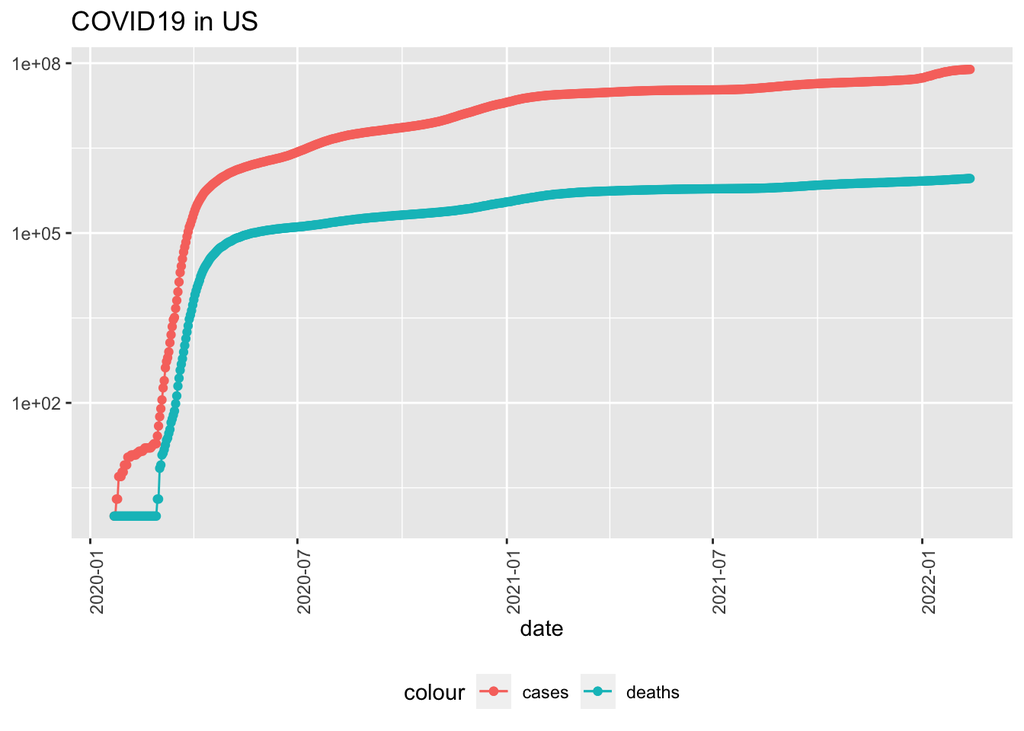

```r
US_totals %>%
   filter(cases > 0) %>%
   ggplot(aes(x = date, y = cases)) +
   geom_line(aes(color = "cases")) +
   geom_point(aes(color = "cases")) +
   geom_line(aes(y = deaths, color = "deaths")) +
   geom_point(aes(y = deaths, color = "deaths")) +
   scale_y_log10() +
   theme(legend.position="bottom",
           axis.text.x = element_text(angle = 90)) +
   labs(title = "COVID19 in US", y = NULL)
```

**Top 5 cases count happened by date wise / Maximum cases in a day :**

```r
US_by_state <- US_by_state %>%
   mutate(new_cases = cases - lag(cases),
           new_deaths = deaths - lag(deaths))

US_totals <- US_totals %>%
   mutate(new_cases = cases - lag(cases),
           new_deaths = deaths - lag(deaths))

tail(US_totals)
```

```
## # A tibble: 6 × 8
##   Country_Region date          cases deaths deaths_per_mill Population new_cases
##   <chr>          <date>        <int>  <int>           <dbl>      <int>     <int>
## 1 US             2022-02-07 76861658 906330           2723.  332875137    338779
## 2 US             2022-02-08 77083020 909233           2731.  332875137    221362
## 3 US             2022-02-09 77270319 912668           2742.  332875137    187299
## 4 US             2022-02-10 77441181 915847           2751.  332875137    170862
## 5 US             2022-02-11 77650446 918451           2759.  332875137    209265
## 6 US             2022-02-12 77707349 919255           2762.  332875137     56903
## # … with 1 more variable: new_deaths <int>
```

```r
tail(US_totals %>% select(new_cases, new_deaths, everything()))
```

```
## # A tibble: 6 × 8
##   new_cases new_deaths Country_Region date          cases deaths deaths_per_mill
##       <int>      <int> <chr>          <date>        <int>  <int>           <dbl>
## 1    338779       2920 US             2022-02-07 76861658 906330           2723.
## 2    221362       2903 US             2022-02-08 77083020 909233           2731.
## 3    187299       3435 US             2022-02-09 77270319 912668           2742.
## 4    170862       3179 US             2022-02-10 77441181 915847           2751.
## 5    209265       2604 US             2022-02-11 77650446 918451           2759.
## 6     56903        804 US             2022-02-12 77707349 919255           2762.
## # … with 1 more variable: Population <int>
```

```r
state <- "NEW YORK"

# sort dataframe by column in r
# select top N results

#spec(US_totals)
#US_totals <- US_totals %>% filter(!is.na(new_cases))
#spec(US_totals)

US_totals_By_Date_TOP_5_Cases_Count <- US_totals[order(-US_totals$new_cases),][1:5,]

US_totals_By_Date_TOP_5_Cases_Count
```

```
## # A tibble: 5 × 8
##   Country_Region date          cases deaths deaths_per_mill Population new_cases
##   <chr>          <date>        <int>  <int>           <dbl>      <int>     <int>
## 1 US             2022-01-10 61690604 842422           2531.  332875137   1368563
## 2 US             2022-01-18 67705084 857674           2577.  332875137   1113068
## 3 US             2022-01-03 56337901 830371           2495.  332875137   1076439
## 4 US             2022-01-19 68703526 861595           2588.  332875137    998442
## 5 US             2022-01-12 63368974 847725           2547.  332875137    909036
## # … with 1 more variable: new_deaths <int>
```

```r
US_totals_By_Date_TOP_Cases <- US_totals_By_Date_TOP_5_Cases_Count[1,]

#US_totals_By_Date_TOP_Cases

# Maximum cases in a day
max(US_totals_By_Date_TOP_Cases$new_cases)
```

```
## [1] 1368563
```

```r
# Maximum cases day - date
max(US_totals_By_Date_TOP_Cases$date)
```

```
## [1] "2022-01-10"
```

## Analizing Data:

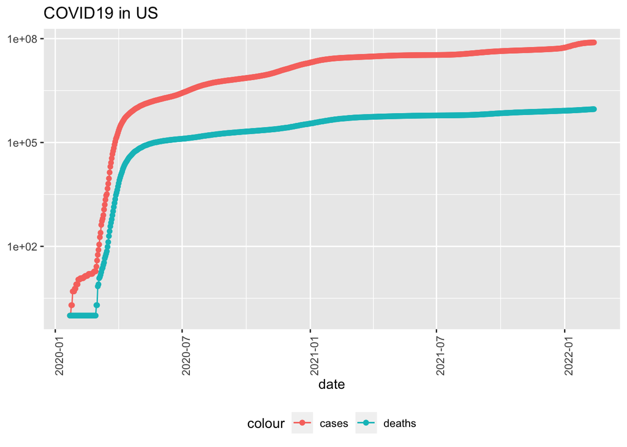

```r
US_totals %>%
   filter(cases > 0) %>%
   ggplot(aes(x = date, y = cases)) +
   geom_line(aes(color = "cases")) +
   geom_point(aes(color = "cases")) +
   geom_line(aes(y = deaths, color = "deaths")) +
   geom_point(aes(y = deaths, color = "deaths")) +
   scale_y_log10() +
   theme(legend.position="bottom",
           axis.text.x = element_text(angle = 90)) +
   labs(title = "COVID19 in US", y = NULL)
```

```r
US_state_totals <- US_by_state %>%
   group_by(Province_State) %>%
   summarize(deaths = max(deaths), cases = max(cases),
               population = max(Population),
               cases_per_thou = 1000* cases / population,
               deaths_per_thou = 1000 * deaths / population) %>%
   filter(cases > 0, population > 0)

US_state_totals %>%
   slice_min(deaths_per_thou, n = 10)
```

```
## # A tibble: 10 × 6
##    Province_State        deaths  cases population cases_per_thou deaths_per_thou
##    <chr>                  <int>  <int>      <int>          <dbl>           <dbl>
##  1 American Samoa             0 1.8 e1      55641          0.324           0
##  2 Northern Mariana Isl…     23 7.35e3      55144        133.              0.417
##  3 Hawaii                  1258 2.31e5    1415872        163.              0.888
##  4 Vermont                  566 1.09e5     623989        175.              0.907
##  5 Virgin Islands           105 1.52e4     107268        142.              0.979
##  6 Puerto Rico             4025 4.69e5    3754939        125.              1.07
##  7 Utah                    4261 9.11e5    3205958        284.              1.33
##  8 Maine                   1828 1.88e5    1344212        140.              1.36
##  9 Washington             11316 1.41e6    7614893        185.              1.49
## 10 Alaska                  1114 2.32e5     740995        313.              1.50
```

```r
US_state_totals <- US_state_totals %>%
  slice_min(deaths_per_thou, n = 10) %>%
  select(deaths_per_thou, cases_per_thou, everything())

US_state_totals
```

```
## # A tibble: 10 × 6
##    deaths_per_thou cases_per_thou Province_State        deaths  cases population
##              <dbl>          <dbl> <chr>                  <int>  <int>      <int>
##  1           0              0.324 American Samoa             0 1.8 e1      55641
##  2           0.417        133.    Northern Mariana Isl…     23 7.35e3      55144
##  3           0.888        163.    Hawaii                  1258 2.31e5    1415872
##  4           0.907        175.    Vermont                  566 1.09e5     623989
##  5           0.979        142.    Virgin Islands           105 1.52e4     107268
##  6           1.07         125.    Puerto Rico             4025 4.69e5    3754939
##  7           1.33         284.    Utah                    4261 9.11e5    3205958
##  8           1.36         140.    Maine                   1828 1.88e5    1344212
##  9           1.49         185.    Washington             11316 1.41e6    7614893
## 10           1.50         313.    Alaska                  1114 2.32e5     740995
```

```r
summary(US_state_totals)
```

```
##  deaths_per_thou  cases_per_thou     Province_State         deaths
##  Min.   :0.0000   Min.   :  0.3235   Length:10          Min.   :    0.0
##  1st Qu.:0.8931   1st Qu.:134.9147   Class :character   1st Qu.:  220.2
##  Median :1.0254   Median :152.3341   Mode  :character   Median : 1186.0
##  Mean   :0.9942   Mean   :165.9996                      Mean   : 2449.6
##  3rd Qu.:1.3522   3rd Qu.:182.5895                      3rd Qu.: 3475.8
##  Max.   :1.5034   Max.   :313.2302                      Max.   :11316.0
##      cases           population
##  Min.   :     18   Min.   :  55144
##  1st Qu.:  38629   1st Qu.: 236448
##  Median : 209338   Median :1042604
##  Mean   : 357240   Mean   :1891891
##  3rd Qu.: 409479   3rd Qu.:2758436
##  Max.   :1410596   Max.   :7614893
```

# 4. Model Building - Linear Regression model

```r
mod <- lm(deaths_per_thou ~ cases_per_thou, data = US_state_totals)

# Sumamry - Model

summary(mod)
```

```
##
## Call:
## lm(formula = deaths_per_thou ~ cases_per_thou, data = US_state_totals)
##
## Residuals:
##     Min      1Q  Median      3Q     Max
## -0.4347 -0.1682 -0.1090  0.2158  0.4807
##
## Coefficients:
##                Estimate Std. Error t value Pr(>|t|)
## (Intercept)    0.270574   0.226618   1.194  0.26669
## cases_per_thou 0.004359   0.001223   3.563  0.00737 **
## ---
## Signif. codes:  0 '***' 0.001 '**' 0.01 '*' 0.05 '.' 0.1 ' ' 1
##
## Residual standard error: 0.318 on 8 degrees of freedom
## Multiple R-squared:  0.6135, Adjusted R-squared:  0.5651
## F-statistic:  12.7 on 1 and 8 DF,  p-value: 0.007366
```

```r
US_state_totals %>% slice_min(cases_per_thou)
```

```
## # A tibble: 1 × 6
##   deaths_per_thou cases_per_thou Province_State deaths cases population
##             <dbl>          <dbl> <chr>           <int> <int>      <int>
## 1               0          0.324 American Samoa      0    18      55641
```

```r
US_state_totals %>% slice_max(cases_per_thou)
```

```
## # A tibble: 1 × 6
##   deaths_per_thou cases_per_thou Province_State deaths  cases population
##             <dbl>          <dbl> <chr>           <int>  <int>      <int>
## 1            1.50           313. Alaska           1114 232102     740995
```

```r
x_grid <- seq(1, 151)

new_df <- tibble(cases_per_thou = x_grid)

# Create Prediction column from model

US_tot_w_pred <- US_state_totals %>%
  mutate(pred = predict(mod))

US_tot_w_pred
```

```
## # A tibble: 10 × 7
##    deaths_per_thou cases_per_thou Province_State  deaths  cases population  pred
##              <dbl>          <dbl> <chr>            <int>  <int>      <int> <dbl>
##  1           0              0.324 American Samoa       0 1.8 e1      55641 0.272
##  2           0.417        133.    Northern Maria…     23 7.35e3      55144 0.852
##  3           0.888        163.    Hawaii            1258 2.31e5    1415872 0.982
##  4           0.907        175.    Vermont            566 1.09e5     623989 1.03
##  5           0.979        142.    Virgin Islands     105 1.52e4     107268 0.888
##  6           1.07         125.    Puerto Rico       4025 4.69e5    3754939 0.815
##  7           1.33         284.    Utah              4261 9.11e5    3205958 1.51
##  8           1.36         140.    Maine             1828 1.88e5    1344212 0.879
##  9           1.49         185.    Washington       11316 1.41e6    7614893 1.08
## 10           1.50         313.    Alaska            1114 2.32e5     740995 1.64
```

```r
summary(US_tot_w_pred)
```

```
##  deaths_per_thou  cases_per_thou     Province_State         deaths
##  Min.   :0.0000   Min.   :  0.3235   Length:10          Min.   :    0.0
##  1st Qu.:0.8931   1st Qu.:134.9147   Class :character   1st Qu.:  220.2
##  Median :1.0254   Median :152.3341   Mode  :character   Median : 1186.0
##  Mean   :0.9942   Mean   :165.9996                      Mean   : 2449.6
##  3rd Qu.:1.3522   3rd Qu.:182.5895                      3rd Qu.: 3475.8
##  Max.   :1.5034   Max.   :313.2302                      Max.   :11316.0
##      cases           population           pred
##  Min.   :     18   Min.   :  55144   Min.   :0.2720
##  1st Qu.:  38629   1st Qu.: 236448   1st Qu.:0.8587
##  Median : 209338   Median :1042604   Median :0.9346
##  Mean   : 357240   Mean   :1891891   Mean   :0.9942
##  3rd Qu.: 409479   3rd Qu.:2758436   3rd Qu.:1.0665
##  Max.   :1410596   Max.   :7614893   Max.   :1.6360
```

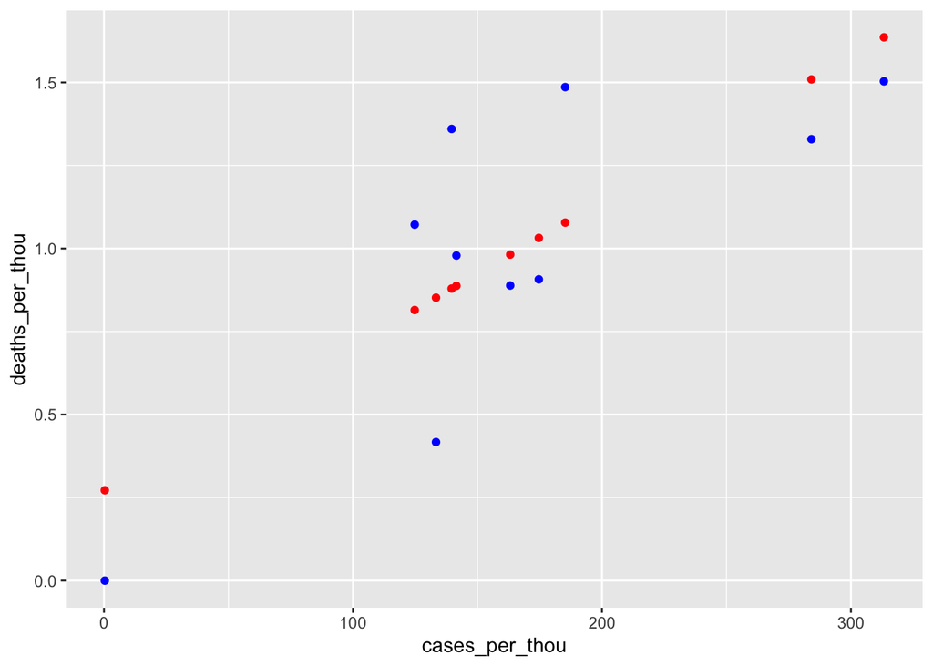

```r
# global_cases <- global_cases %>%
#    mutate(date = mdy(date))

# Model plot - Visualization

US_tot_w_pred %>% ggplot() +
 geom_point(aes(x = cases_per_thou, y = deaths_per_thou), color = "blue") +
 geom_point(aes(x = cases_per_thou, y = pred), color = "red")
```

## Model Performance and Coefficients: – a and b values vary

# 5. Bias:

**Selection Bias:** This seems like not an issue as this data is from John Hopkins github.

**Overfitting and Underfitting:** When a model gets trained with large amounts of data, it also starts learning from the noise and inaccurate data entries in the dataset. Consequently, the model does not categorize the data correctly, because of too many details and noise. In this data set, lat lang or many other features can cause noise but can be reduced.

**Exclusion Bias:** It’s possible excluding some features can cause higher bias and this can be reduced including some features that can reduce bias like climate and economic situations and political situations, and inflation and seasons can be included to get more accurate model performance.

# Conclusion:

To conclude, I have done the Visualizations, Model, and Bias from the above. The answers are as follows:  
1. Summarized Global/US cases and deaths separately.  
2. Visualized state-wise cases/deaths using plots, Analyzed state-wise data, Analyzed state-wise maximum cases and deaths.  
3. Prepared data for the Model  
a. LM model building  
b. Summarized and analyzed model.  
c. Understanding model predictions and plotting the model prediction visually.